# Análise Exploratória dos Dados

Agnaldo Xavier, Ariann Farias, Dayvson Nascimento, Raquel Ambrozio, Victor Araujo

12 de novembro de 2018

Foram selecionadas 60 reclamações, sendo metade referente o Instituto Nacional do Seguro Social (INSS) e a outra metdade à Agência Nacional de Aviação Civil (ANAC) realizadas pelo portal ReclameAqui. Adicionalmente levando em consideração o experimento humano realizado com 37 alunos da disciplina sobre o nível de insatisfação da amostra de reclamações, Efetuado na disciplina de Metodologia Científica do curso de Ciência da Computação da Universidade Federal de Campina Grande (UFCG).

## Preparação do ambiente

```r
library(tidyverse)
library(ggplot2)

reclamacoes <- read_csv("/home/agnaldosxj/reclamacoes-do-gf/data/1-reclamacoes-selecionadas/20181610-reclamacoes-selecionadas.csv")
avaliacoes <- read_csv("/home/agnaldosxj/reclamacoes-do-gf/data/3-avaliacao-humana/avaliacoes-20181030.csv")
```

```r
names(reclamacoes)
```

```
## [1] "Grupo_de_Avaliacao" "Orgao"              "Titulo"
## [4] "Reclamacao"         "ID"
```

```r
names(avaliacoes)
```

```
## [1] "Matricula"            "ID_Reclamacao"        "Grau_de_Insatisfacao"
```

# Análise

## Será que existe relação entre tamanho da reclamação e cada orgão governamental?

```r
reclamacoes$Palavras = str_count(reclamacoes$Reclamacao,'\\w{2,}') + str_count(reclamacoes$Titulo,'\\w{2,}')
```

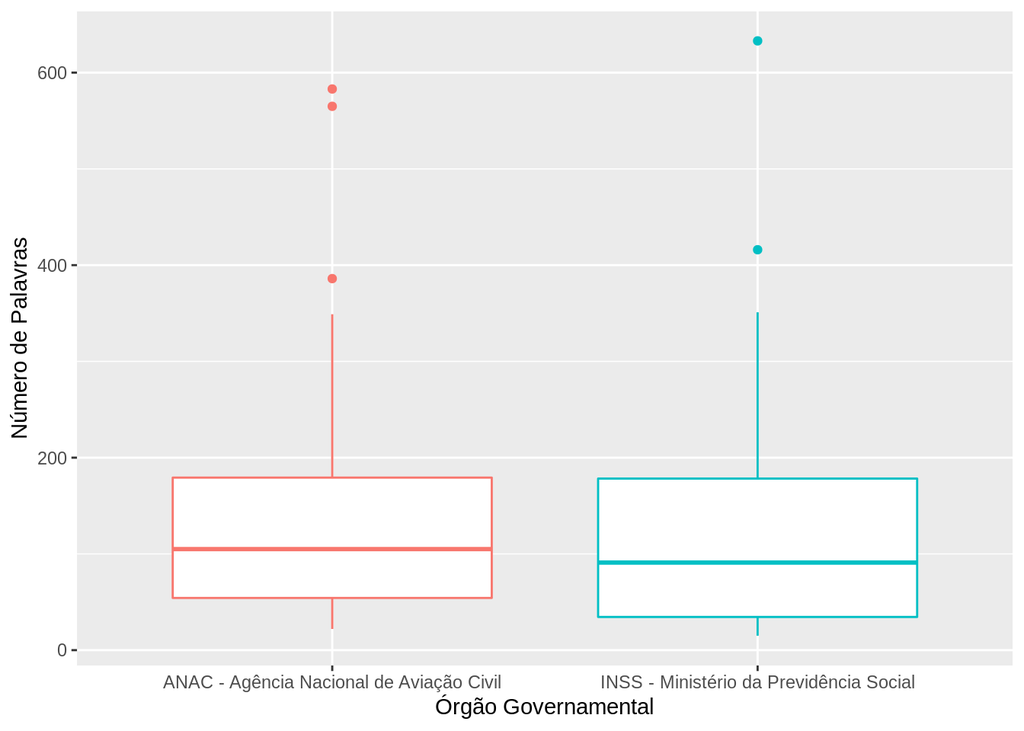

```r
reclamacoes %>%
    group_by(Orgao) %>%
    ggplot(aes(x = Orgao, y = Palavras)) +
    xlab("Órgão Governamental") + ylab("Número de Palavras") +
    geom_boxplot(aes(color = Orgao), show.legend=FALSE)
```

A npartir da mediana notamos que o do número de palavras por reclamação, referentes à ANAC, são levemente superiores. Todavia, reclamações feitas para este órgão são de tamanho mais homogêneo. Desta forma, podemos concluir que as reclamações para ambos os órgãos (ANAC e do INSS) são semelhantes em número de palavras que cada uma contém.

## Será que existe relação entre o uso de caixa alta e o órgão governamental?

```r
reclamacoes$Palavras_CAPS = str_count(reclamacoes$Reclamacao,'\\b[A-Z]{2,}\\b') + str_count(reclamacoes$Titulo,'\\b[A-Z]{2,}\\b')
```

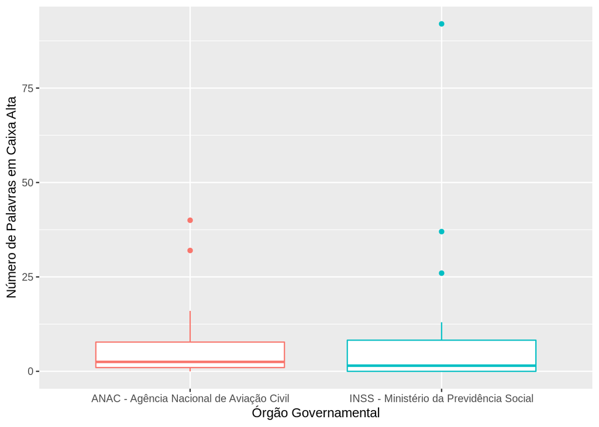

```r
reclamacoes %>%
    group_by(Orgao) %>%
    ggplot(aes(x = Orgao, y = Palavras_CAPS)) +
    xlab("Órgão Governamental") + ylab("Número de Palavras em Caixa Alta") +
    geom_boxplot(aes(color = Orgao), show.legend=FALSE)
```

As reclamações feitas ao INSS e à ANAC ao relacionar com o uso de caixa alta, são visívelmente semelhantes. Para mais é notável que a proporção de palavras em caixa alta é pequena na amostra de reclamações avaliadas.

## Será que há consenso entre as avaliações de cada reclamação?

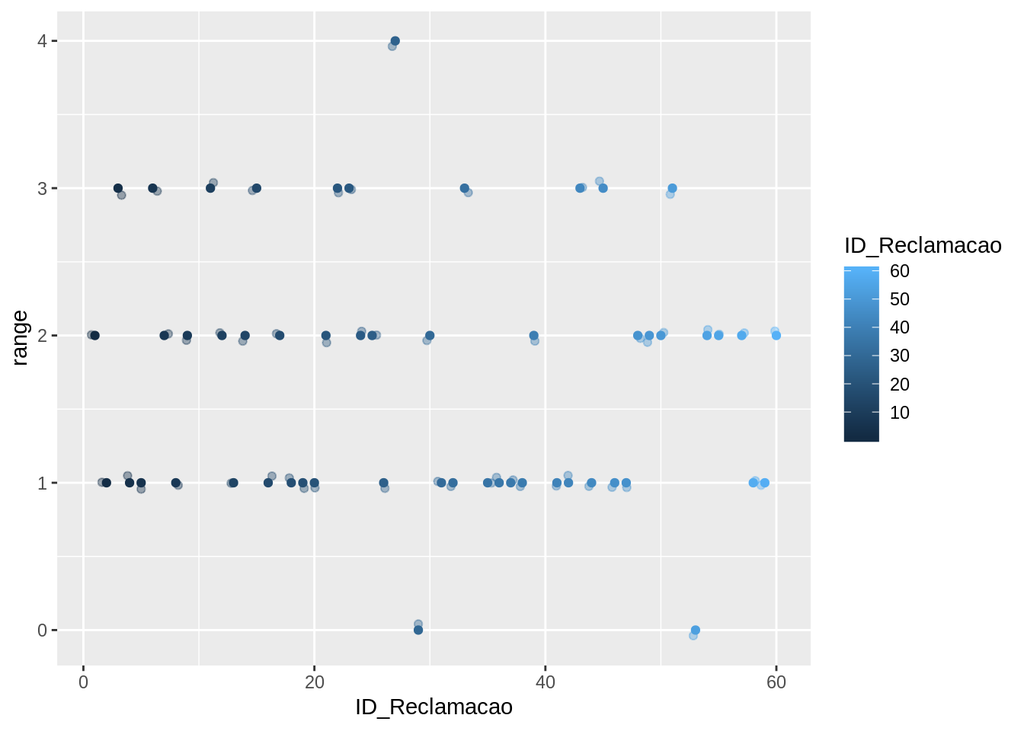

```r
avaliacoes %>% group_by(ID_Reclamacao) %>%
  summarise(range = max(Grau_de_Insatisfacao) - min(Grau_de_Insatisfacao),
            mediana = median(Grau_de_Insatisfacao)) %>%
  ggplot(aes(x=ID_Reclamacao, y=range, colour = ID_Reclamacao)) + geom_point() +
geom_jitter(height = 0.05, alpha = .4)
```